# Local Dimension Diagnostic Validation

## Purpose

This report validates the local dimension diagnostic used by the geodesic pathwise annihilator experiments. For each local graph disk $B_G(v,\varepsilon_v)$, the diagnostic embeds the induced weighted graph in dimensions $q=1,\ldots,q_{\max}$ and measures the relative edge-length stress

$$E_q(v)
=
\left(
\frac{\sum_{(i,j)\in E_v}(\|z_i-z_j\|-\ell_{ij})^2}
{\sum_{(i,j)\in E_v}\ell_{ij}^2}
\right)^{1/2}.$$

The selected dimension is obtained from an edge-stress elbow rule. This is not a theorem about intrinsic dimension; it is an engineering diagnostic that should behave correctly on controlled examples before it is used to guide row thinning or local polynomial-basis construction.

The report also compares two additional estimators. The metric-MDS spectrum elbow estimates dimension from the positive eigenvalue spectrum of the local graph-geodesic distance matrix. The graph-Laplacian Weyl estimator fits a local log-count/log-eigenvalue slope,

$$N(\lambda)\approx C\lambda^{m/2},$$

and reports $m\approx 2\,d\log N/d\log\lambda$. These estimators are not expected to agree on every finite graph disk, but systematic disagreement is a useful diagnostic of estimator calibration.

The validation ladder includes 1D path/cycle graphs, noisy circle graphs, regular and warped grids, sampled planar graphs, quadric surface graphs, and 3D cube graphs. The default validation uses `cmdscale`, while the optional `hybrid.edge.kk` method uses weighted GRIP where appropriate and metric MDS followed by edge-KK for dimensions above three when the installed `grip` namespace provides those functions. Noisy circles are treated as transition cases: as radial noise increases, a growing fraction of dimension-2 selections is reasonable.

## Stress Curves

The first check looks at the full stress profile

$$E_1(v),\quad E_2(v),\quad E_3(v)$$

for sampled local disks. A 1D graph should be well represented in dimension one. A 2D graph should usually show a sharp drop from dimension one to two and little additional gain afterward. A 3D graph should often continue improving through dimension three and then stabilize.

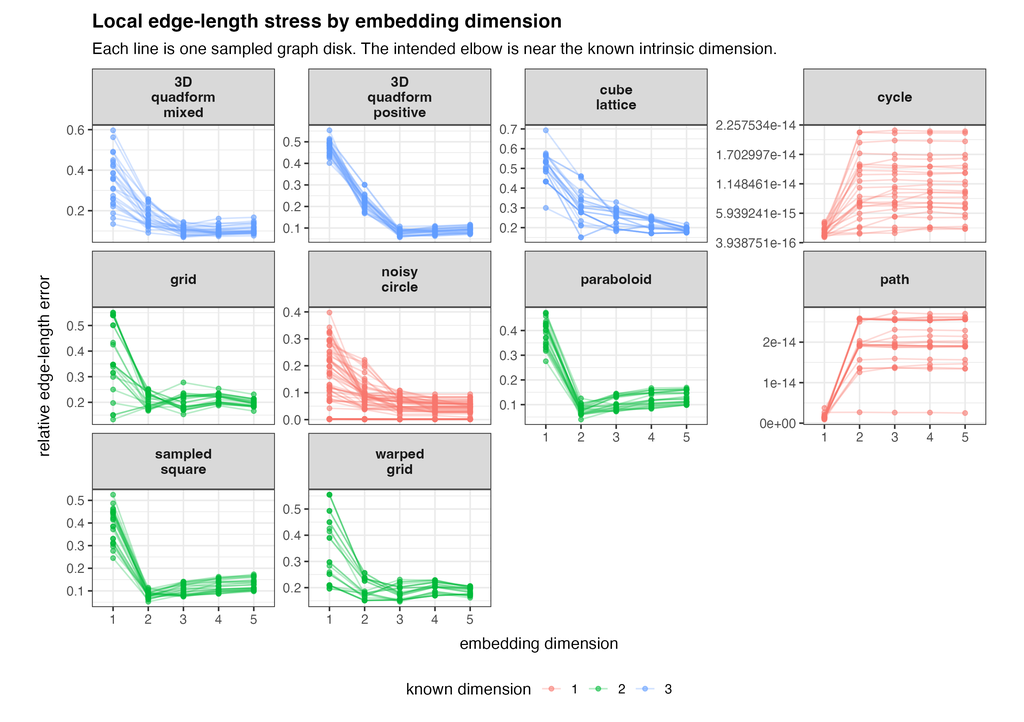

The most important visual cue is the shape of the curve, not only the selected dimension. Strong 1-to-2 improvement in surface-like examples supports a local 2D interpretation. Continued improvement into dimension three is expected for volumetric examples and should be treated as a cap warning if the final stress remains high.

## Selected Dimension

The next figure summarizes the selected local dimension directly. Strict accuracy is meaningful for the non-transition cases. For noisy circles, the selected dimension is interpreted as a noise-response curve rather than a hard classification target.

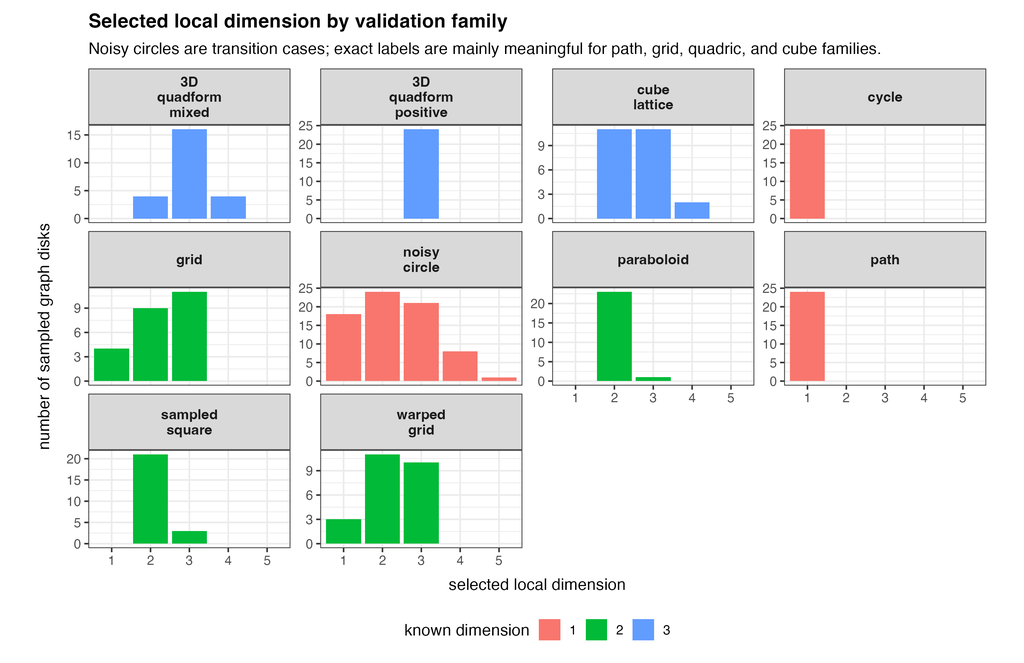

For clean path and cycle graphs, dimension one should dominate. For grids, sampled planar graphs, and quadric surfaces, dimension two should dominate, especially away from boundaries. Cube examples should produce many dimension-three selections.

## Estimator Votes

The following plot compares the edge-stress elbow, metric-MDS spectrum elbow, graph-Laplacian Weyl estimator, and simple consensus vote. The aim is not to declare one estimator universally correct; it is to see which controlled graph families produce stable agreement and which ones expose calibration problems.

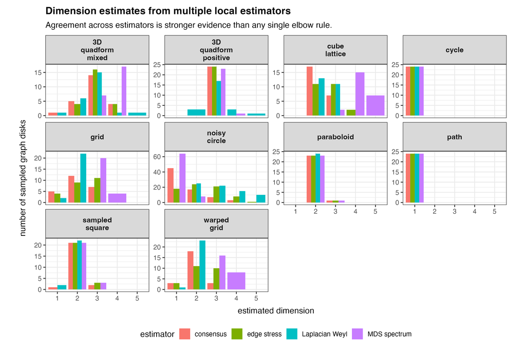

The MDS spectrum estimator asks how many positive metric directions are needed to explain the local graph-geodesic distance geometry. The Laplacian estimator asks how local diffusion eigenvalues scale. The edge-stress estimator asks how well embedded Euclidean edge lengths are realized. These are related but not identical notions of dimension, so disagreement should be inspected rather than automatically averaged away.

## Confusion Matrix

For non-transition examples, the selected dimension can be compared directly with the known dimension.

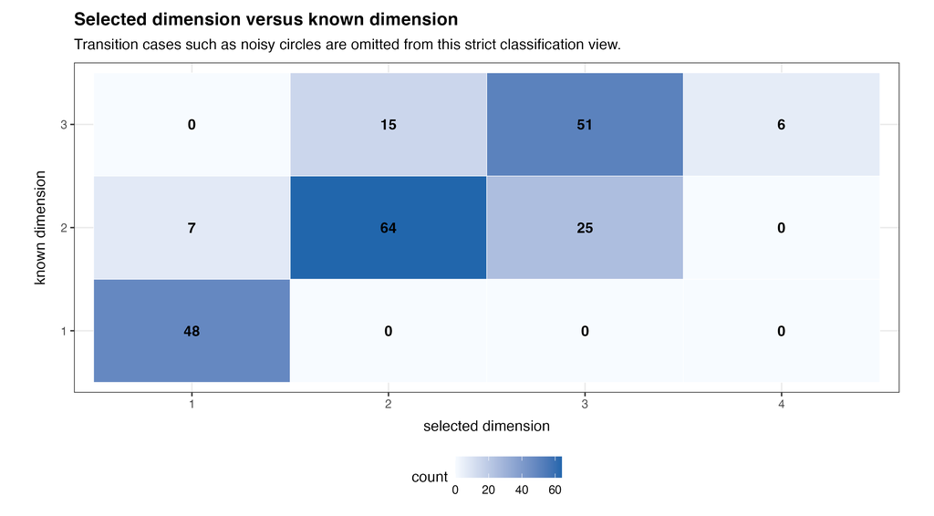

This plot is the strictest validation summary. Off-diagonal mass identifies where the stress-elbow rule is miscalibrated, where graph construction obscures local geometry, or where the disk radius mixes boundary and interior behavior.

## Boundary Versus Interior

Boundary neighborhoods are typically less balanced than interior neighborhoods. This figure separates the selected-dimension distribution by center region.

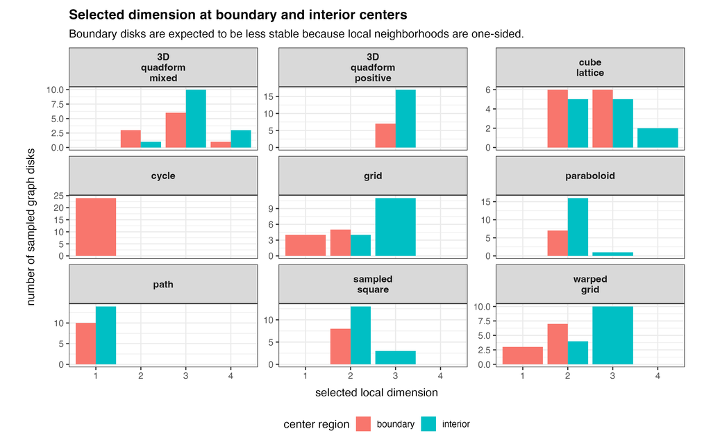

This check is important for deciding when mirror extensions or adaptive radius rules should be used. A method that works only on interiors but fails near boundaries can still be useful, but the boundary behavior needs to be explicit.

## Noisy Circle Transition

The noisy circle benchmark is intentionally not a strict 1D/2D classification problem. Samples are generated near a circle, and a symmetric kNN graph is constructed from the noisy coordinates. As the radial noise level $\sigma$ increases, local disks can become less curve-like and more locally two dimensional.

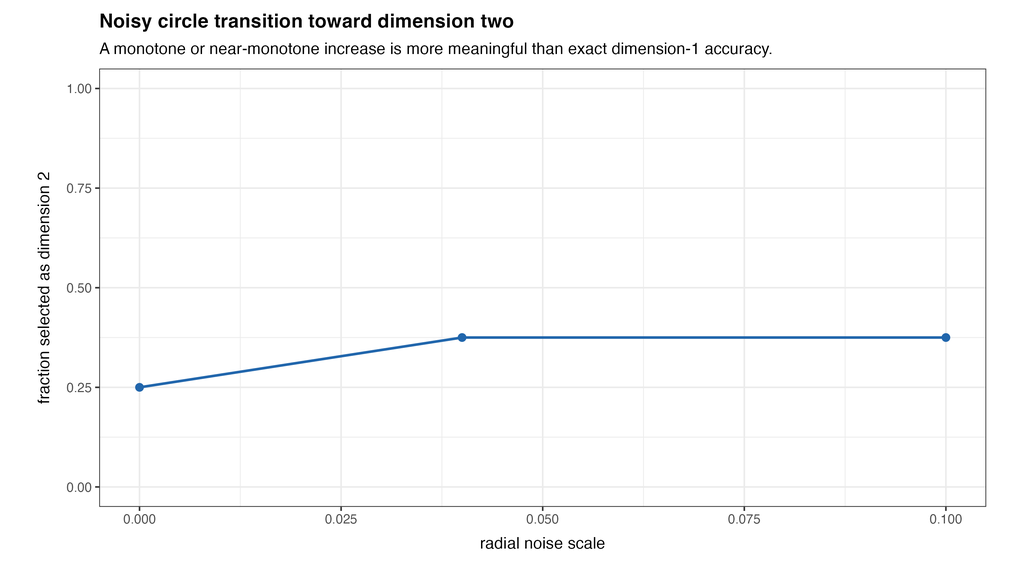

This transition plot tests calibration. The diagnostic should not be forced to call every noisy circle disk one-dimensional if the graph geometry itself has become locally thickened.

## Stress Improvement Ratios

A compact way to inspect the elbow rule is to compare relative stress improvements

$$\Delta_q(v)=\frac{E_{q-1}(v)-E_q(v)}{E_{q-1}(v)}.$$

Large $\Delta_2$ and small $\Delta_3$ is the expected surface signature. Large $\Delta_3$ is the expected volumetric signature.

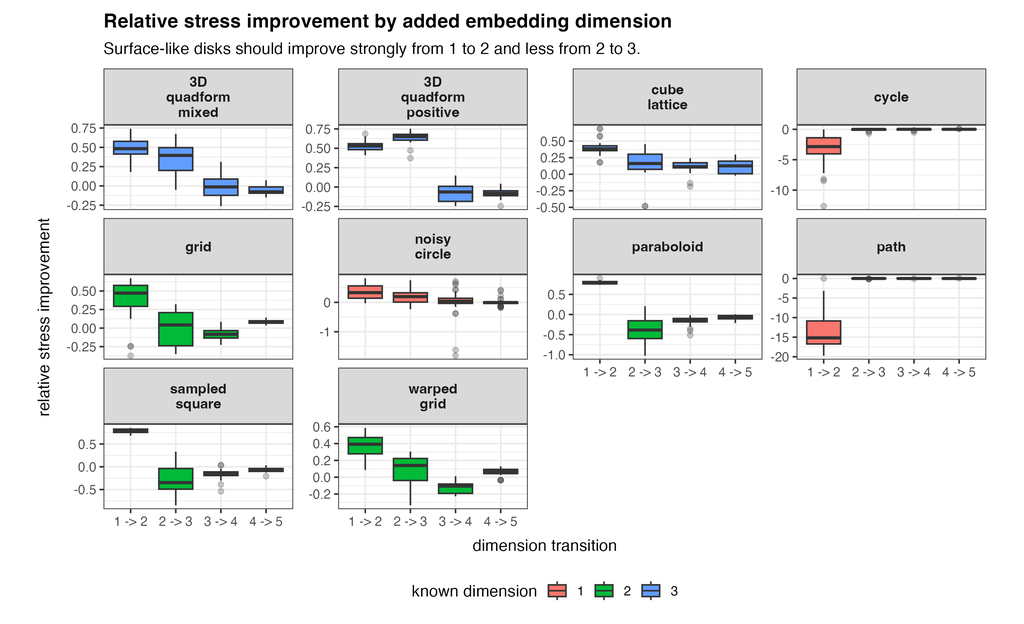

## Results Summary

Across non-transition validation families, the median strict accuracy is 0.875. The median cap-hit rate is 0.000. The noisy-circle cases should be read as a calibration curve: dimension-2 selections are allowed to increase with noise.

The diagnostic is considered useful if it satisfies three conditions. First, the clean 1D, 2D, and 3D examples should produce the corresponding selected dimension for most sampled disks. Second, boundary errors should be visible rather than hidden in a single global score. Third, noisy-circle selections should vary smoothly with noise instead of behaving erratically.

# Appendix

## Run Metadata

```r
result.path
```

```
## [1] "/Users/pgajer/current_projects/gflow/dev/graph-trend-filtering/local-dimension-validation/reports/local_dimension_validation_smoke.rds"
```

```r
diagnostics$mode
```

```
## [1] "smoke"
```

```r
diagnostics$created
```

```
## [1] "2026-05-17 16:48:51 EDT"
```

```r
diagnostics$control
```

```
## $method
## [1] "cmdscale"
##
## $disk.k
## [1] 16
##
## $centers.max
## [1] 24
```

## Summary Table

```r
summary.table
```

```
##                           case.id local.embedding.method               family
## 1                        cycle_72               cmdscale                cycle
## 2                         path_60               cmdscale                 path
## 3      paraboloid_delaunay_seed_1               cmdscale           paraboloid
## 4  sampled_square_delaunay_seed_1               cmdscale       sampled square
## 5                        grid_8x8               cmdscale                 grid
## 6                 warped_grid_8x8               cmdscale          warped grid
## 7  quadform3d_ball_k1_c124_seed_1               cmdscale    3D quadform mixed
## 8  quadform3d_ball_k3_c111_seed_1               cmdscale 3D quadform positive
## 9              cube_lattice_5x5x5               cmdscale         cube lattice
## 10  noisy_circle_sknn_sigma_0.000               cmdscale         noisy circle
## 11  noisy_circle_sknn_sigma_0.040               cmdscale         noisy circle
## 12  noisy_circle_sknn_sigma_0.100               cmdscale         noisy circle
##                 dataset         graph.type true.dimension    expected.class
## 1                 cycle              cycle              1                 1
```

[output cut: 24 more lines]

## Center Selection Table

```r
head(center.table, 80)
```

```
##             case.id      family     dataset graph.type true.dimension
## 1           path_60        path        path       path              1
## 6           path_60        path        path       path              1
## 11          path_60        path        path       path              1
## 16          path_60        path        path       path              1
## 21          path_60        path        path       path              1
## 26          path_60        path        path       path              1
## 31          path_60        path        path       path              1
## 36          path_60        path        path       path              1
## 41          path_60        path        path       path              1
## 46          path_60        path        path       path              1
## 51          path_60        path        path       path              1
## 56          path_60        path        path       path              1
## 61          path_60        path        path       path              1
## 66          path_60        path        path       path              1
```

[output cut: 390 more lines]

## Local Dimension Table

```r
head(local.table, 120)
```

```
##     center local.embedding.method embedding.dim n.local.vertices n.local.edges
## 1        1               cmdscale             1               17            16
## 2        1               cmdscale             2               17            16
## 3        1               cmdscale             3               17            16
## 4        1               cmdscale             4               17            16
## 5        1               cmdscale             5               17            16
## 6        4               cmdscale             1               17            16
## 7        4               cmdscale             2               17            16
## 8        4               cmdscale             3               17            16
## 9        4               cmdscale             4               17            16
## 10       4               cmdscale             5               17            16
## 11       6               cmdscale             1               17            16
## 12       6               cmdscale             2               17            16
## 13       6               cmdscale             3               17            16
## 14       6               cmdscale             4               17            16
```

[output cut: 832 more lines]

## Reproducibility Commands

```r
# Smoke run
GFLOW_LOCAL_DIM_VALIDATION_MODE=smoke \
  Rscript dev/graph-trend-filtering/local-dimension-validation/render_local_dimension_validation.R

# Full run
GFLOW_LOCAL_DIM_VALIDATION_MODE=full \
  Rscript dev/graph-trend-filtering/local-dimension-validation/render_local_dimension_validation.R
```